# Tampa Bay Rays

[figure not shown]

## Background

After coming off of a shortened season in 2020, many players and fans are very excited for this season of baseball. After a total of 70 games played, the Tampa Bay Rays are leading the league in number of strikeouts (735). They also currently have the best win to lost record in their division with 43 wins and 27 loses. The next closest team in strikeouts are the Detroit Tigers (697). The Detroit Tigers have a total of 29 wins and 40 loses. How are the Tampa Bay Rays winning while leading the league in number of strikeouts? Is there a relationship between the number of strikeouts in a game and the number of runs scored? Is there a difference in the number of strikeouts and runs per game between wins and losses?

## The Data

To be able to see if there is a relationship between the number of strikeouts in a game and the number of runs scored, I collected the number of strikeouts the Tampa Bay Rays had in that game. I also collected the number of runs the Tampa Rays scored in that game. The complete data set is below:

```r
tampa <- baseball %>%
  select(-Game)
datatable(tampa, options=list(lengthMenu = c(10,20,40)), extensions="Responsive")
```

|  | Strikeouts | Runs | Opponents | W.L |
| --- | --- | --- | --- | --- |
| 1 | 12 | 1 | Marlins | W |
| 2 | 6 | 7 | Marlins | L |
| 3 | 13 | 5 | Red Sox | L |
| 4 | 11 | 10 | Yankees | W |
| 5 | 13 | 4 | Yankees | L |
| 6 | 6 | 3 | Rangers | L |
| 7 | 12 | 4 | Rangers | L |
| 8 | 12 | 6 | Yankees | W |
| 9 | 12 | 4 | Royals | W |
| 10 | 7 | 8 | Royals | L |

[output cut: 25 more lines]

## Hypothesis

### Test for Equal y-intercept

$$H_0: \beta_2 = 0 \quad \text{(Equal average number of runs scored in a
game)} \\
H_a: \beta_2 \neq 0 \quad \text{(Non-equal average number of runs
scored in a game)}$$

### Test for Equal slope

If $\beta_3$ is zero, then the slopes of the two lines are the same. This would imply that the number of strikeouts is the same for both wins and loses. However, if the slopes differ, i.e., $\beta_3 \neq 0$, then either win or loses have more or less strikeouts than the other. These hypotheses will be judged at the $\alpha=0.05$ significance level.

$$H_0: \beta_3 = 0 \quad \text{(Equal number of strikeouts)} \\
H_a: \beta_3 \neq 0 \quad \text{(Non-equal number of strikeouts)}$$

## Test

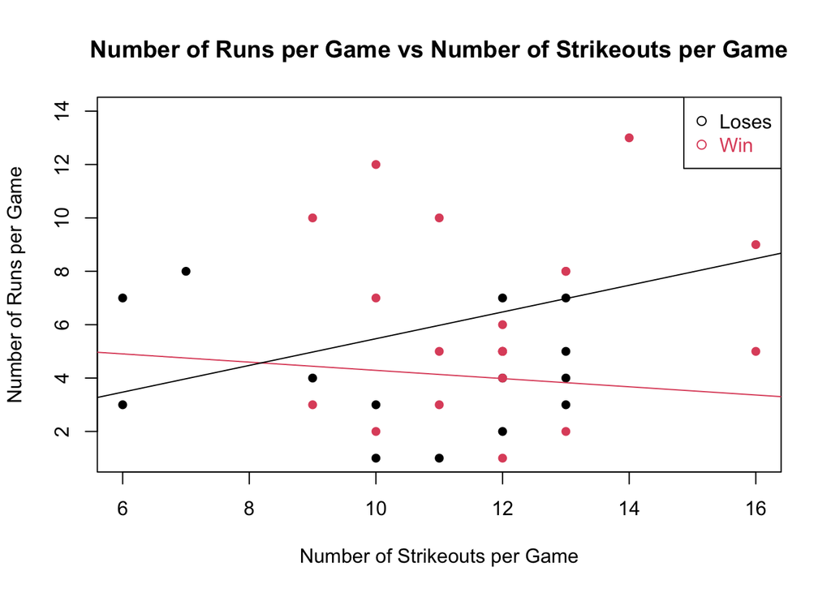

```r
baseball.lm <- lm(Runs ~ Strikeouts + W.L + Strikeouts:W.L, data = baseball)
coef <- coef(baseball.lm)

plot(Runs ~ Strikeouts, data = baseball, col=as.factor(W.L),pch=16, main = "Number of Runs per Game vs Number of Strikeouts per Game", ylab = "Number of Runs per Game" , xlab = "Number of Strikeouts per Game")
abline(a=coef[1],b=coef[2],col=2)
abline(a=coef[1]+coef[3],b=coef[2]+coef[4],col=1)
legend("topright", col=palette(), pch=21, legend=c("Loses", "Win"),  text.col = c(1,2))
```

```r
summary(baseball.lm) %>%
  pander()
```

|  | Estimate | Std. Error | t value | Pr(>\|t\|) |
| --- | --- | --- | --- | --- |
| **(Intercept)** | 5.834 | 3.716 | 1.57 | 0.1266 |
| **Strikeouts** | -0.1543 | 0.3443 | -0.4481 | 0.6572 |
| **W.LW** | -5.365 | 5.62 | -0.9546 | 0.3472 |
| **Strikeouts:W.LW** | 0.6548 | 0.4865 | 1.346 | 0.188 |

Fitting linear model: Runs ~ Strikeouts + W.L + Strikeouts:W.L

| Observations | Residual Std. Error | $R^2$ | Adjusted $R^2$ |
| --- | --- | --- | --- |
| 35 | 3.22 | 0.1765 | 0.09676 |

```r
baseball.lm <- lm(Runs ~ Strikeouts + Strikeouts:W.L, data = baseball)
summary(baseball.lm) %>%
  pander()
```

|  | Estimate | Std. Error | t value | Pr(>\|t\|) |
| --- | --- | --- | --- | --- |
| **(Intercept)** | 3.489 | 2.784 | 1.253 | 0.2192 |
| **Strikeouts** | 0.05712 | 0.2632 | 0.217 | 0.8296 |
| **Strikeouts:W.LW** | 0.2008 | 0.1017 | 1.973 | 0.05716 |

Fitting linear model: Runs ~ Strikeouts + Strikeouts:W.L

| Observations | Residual Std. Error | $R^2$ | Adjusted $R^2$ |
| --- | --- | --- | --- |
| 35 | 3.216 | 0.1522 | 0.09926 |

## Show Assumption

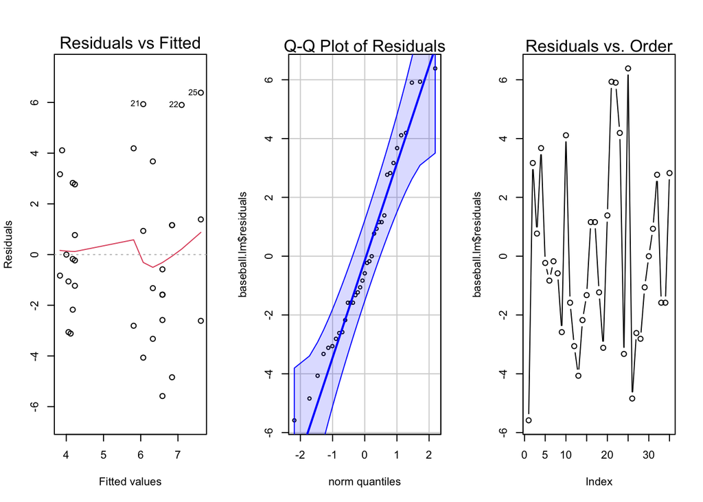

```r
par(mfrow=c(1,3))
plot(baseball.lm, which=1)
qqPlot(baseball.lm$residuals, id = FALSE)
mtext(side=3,text="Q-Q Plot of Residuals")
plot(baseball.lm$residuals, type="b")
mtext(side=3, text="Residuals vs. Order")
```

We can assume that this test will be okay to use for our analysis, because the red line in the Residual vs. Fitted plot is not very dramatic. In the Q-Q Plot, it does not show any of the dots out side of the dashed dotted line. The data points 21 and 22 seem to be outliers, but we will leave the data points in and work around this problem.

The Residuals vs Fitted checks the assumptions 1 and 3. If there is no pattern found in the Residuals vs. Fitted graph then assumptions are met. The Normal Q-Q plot, which is the middle graph, checks the second assumption. If the residuals follow the line, then the assumption was met. The Residuals vs. Order plot checks the 5th assumption. If there is no pattern found in the first glance then the assumption is met.

## Conclusion

As we look at the results from our test, we can conclude that their is insufficient evidence to reject the null hypothesis for both equal y-intercept ($\text{p-value}= 0.3472$, $\alpha < \text{p-value}$) and equal slope ($\text{p-value}= 0.188$, $\alpha < \text{p-value}$). Even after we drop $beta_2$, all the p-values are still larger than the alpha.This means that we cannot conclude that there is a difference between the average number of runs scored per game if there were zero strikeouts for both wins and loses. We also cannot conclude that there is a difference between the relationship between strikeouts and runs per game when compared to wins and loses.